# Caso Ikognitive

Ikonosoft S A S

# Situación

Una empresa multinacional de alimentos quería entender el comportamiento un perfil de consumidor específico. Para ello, realizó una encuesta y recopiló información de redes sociales de 100 personas bajo su permiso.

# Proceso de Construcción de un Tablero Customer Journey

Cada cliente presenta requerimientos funcionales distintos para la construcción de un tablero Customer Journey. Estos requerimientos funcionales son identificados en un proceso inicial de levantamiento de información. De nuestros tableros Customer Journey hacemos énfasis en las siguientes funciones:

- Segmentar clientes objetivo.
- Medir interacciones de clientes objetivo con redes sociales.
- Analizar sentimientos de los clientes (positivos, negativos, neutros), asociados a sus temas de interés.

El diseño y desarrollo del software con sus respectivas pruebas de validación se realizan con el propósito de garantizar dichos requerimientos funcionales. Una vez llevados a cabo, tiene lugar el lanzamiento o puesta en funcionamiento del Tablero Customer Journey.

Asimismo, a través de nuestras alternativas de soporte, nuestros clientes tienen la posibilidad de modificar o actualizar sus tableros Customer Journey para responder a nuevos requerimientos del entorno.

# Visualización de Tablero Customer Journey

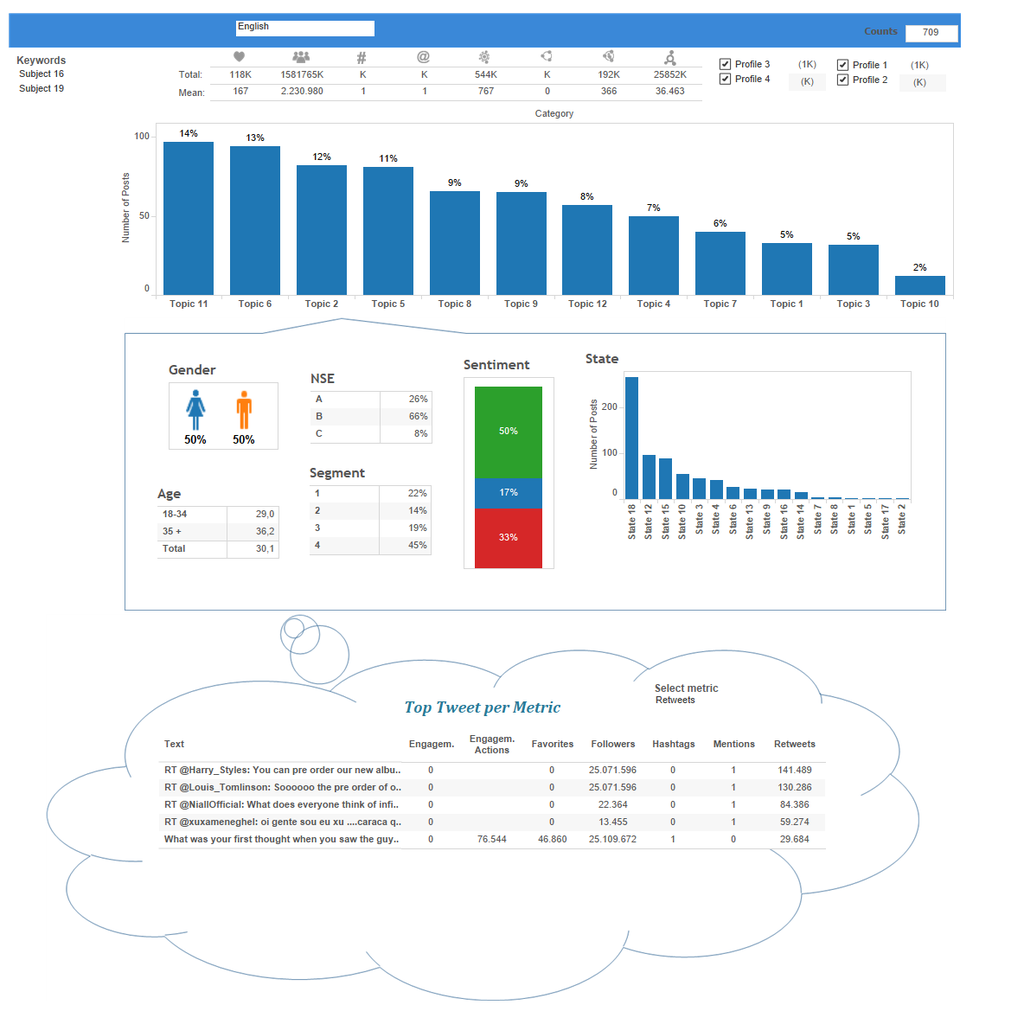

# Beneficios de la Implementación de Tablero Customer Journey

Nuestros tableros Customer Journey han permitido a nuestros clientes visualizar información social relevante de manera óptima y emplearla con los siguientes propósitos:

- Construir modelos de experiencia de clientes.
- Identificar tendencias sociales de segmentos de clientes objetivo.
- Formular estrategias de adquisición y retención de segmentos de clientes.